# Day 1 - Module 01: Warming up

UM Bioinformatics Core

# 1 Warming Up

In this module, we will:

- cover basic materials needed
- familiarize ourselves with remote computing
- prepare for later modules

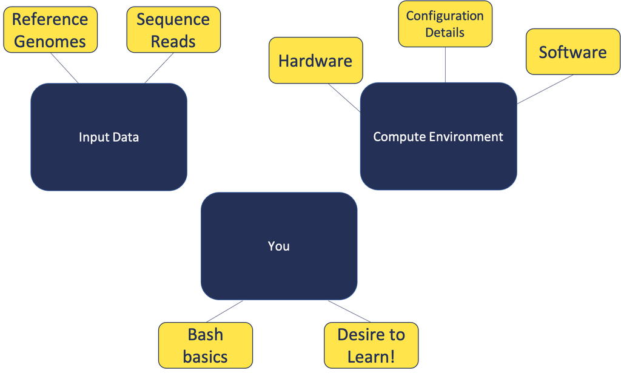

## 1.1 Local vs remote exercise:

1. Become familiar with the different appearance of the local shell
2. Create local folder `~/workshop_rsd` for results
3. Log in to the aws instance with `ssh <username>@50.17.210.255`
4. Become familiar with appearance of the remote shell

**Click here for hints - Local vs remote exercise**

1. Familiarize with local shell appearance
2. Create local folder for results

   ```
    mkdir ~/workshop_rsd
   ```

3. Log in to aws instance

   ```
    ssh <username>@50.17.210.255
   ```

4. Become familiar with the differences between local and remote shell

**Click here for demonstration of local (git-bash on Windows) vs remote (AWS)**

[figure not shown]

## 1.2 Orientation exercise

Note: We will provide additional time during this exercise to ensure that everyone is prepared to move forward.

Orientation exercise:

1. Log in (or confirm logged in) to aws instance
2. Ensure in home directory with `cd`
3. Use `cp` to copy the data from `/rsd/data/` to your home directory
4. Use `ls` to view references
5. Use `ls` to view input fastq files
6. Use `mkdir` to create a folder for our analysis

**Click here for solution**

1. Ensure we’re logged in to remote

   ```
    ssh <username>@50.17.210.255
   ```

2. Ensure we are in home directory

   ```
    cd
   ```

3. Copy data to our home directory

   ```
    cp -r /rsd/data/ ~/
   ```

4. View our references

   ```
    ls ~/data/refs
   ```

5. View our input fastq files

   ```
    ls ~/data/reads
   ```

6. Create a folder for our analysis

   ```
    mkdir ~/analysis
   ```

## 1.3 Bonus exercise:

1. Ensure we’re on remote aws instance
2. run the command `fortune | cowsay | lolcat`

Optional and only for fun!

These programs are installed ‘games’ for entertainment purposes.

**Details about `fortune | cowsay | lolcat`**

`fortune` prints a random fortune

`cowsay` is a talking cow

`lolcat` is like `cat` but with a fun twist

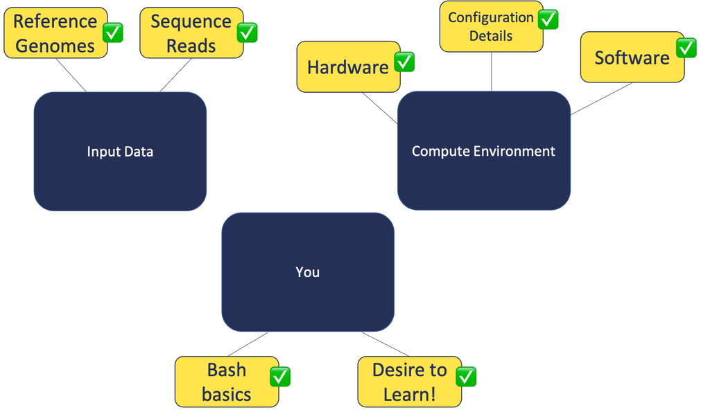